# Biostat 212a Homework 1

Due Jan 23, 2024 @ 11:59PM

Author

Chengwu Duan (Jason) and 606332825

Published

January 24, 2024

## 1 Filling gaps in lecture notes (10pts)

Consider the regression model
$$Y = f(X) + \epsilon,$$
where $\operatorname{E}(\epsilon) = 0$.

### 1.1 Optimal regression function

Show that the choice
$$f_{\text{opt}}(X) = \operatorname{E}(Y | X)$$
minimizes the mean squared prediction error

$$\operatorname{E}[(Y - f(X))^2],$$

where the expectations averages over variations in both $X$ and $Y$. (Hint: condition on $X$.)

**Answer:**
$$\begin{align*}
\operatorname{E}\{[Y - f(X)]^2\} & = \operatorname{E}\{[Y - \operatorname{E}(Y|X)+\operatorname{E}(Y|X)-f(X)]^2\}\\
& =\operatorname{E}\{[(Y - \operatorname{E}(Y|X))+(\operatorname{E}(Y|X)-f(X))]^2\}\\
& =\operatorname{E}\{[Y-E(Y|X)]^2\}+\operatorname{E}\{[E(Y|X)-f(X)]^2\}+\underbrace{2\operatorname{E}\{[E(Y|X)-f(X)][Y-E(Y|X)]\}}_{(3)}\\
(3)&=2\operatorname{E}\{[E(Y|X)-f(X)][Y-E(Y|X)]\}\\
&=2\operatorname{E}\{{\operatorname{E}\{[E(Y|X)-f(X)][Y-E(Y|X)]\}|X}\} \text{(Law of total expectation)}\\
&=2\operatorname{E}\{[E(Y|X)-f(X)]\underbrace{[E(Y|X)-E(Y|X)]}_{=0}\}\\
\operatorname{E}\{[Y - f(X)]^2\}
& =\operatorname{E}\{[Y-E(Y|X)]^2\}+\operatorname{E}\{\underbrace{[E(Y|X)-f(X)]^2}_{\geq0}\}\\
\operatorname{E}\{[Y - f(X)]^2\}&\geq\underbrace{\operatorname{E}\{[Y-E(Y|X)]^2\}}_{\text{Irreducible}}
\end{align*}$$

### 1.2 Bias-variance trade-off

Given an estimate $\hat f$ of $f$, show that the test error at a $x_0$ can be decomposed as
$$\operatorname{E}[y_0 - \hat f(x_0)]^2 = \underbrace{\operatorname{Var}(\hat f(x_0)) + [\operatorname{Bias}(\hat f(x_0))]^2}_{\text{MSE of } \hat f(x_0) \text{ for estimating } f(x_0)} + \underbrace{\operatorname{Var}(\epsilon)}_{\text{irreducible}},$$
where the expectation averages over the variability in $y_0$ and $\hat f$.

**Answer:**
$$\begin{align*}
\operatorname{E}[y_0 - \hat f(x_0)]^2 & = \operatorname{E}[(y_0 - f(x_0) + f(x_0) - \hat f(x_0)]^2\\
& =\operatorname{E}[(y_0 - f(x_0))^2 + (f(x_0) - \hat f(x_0))^2 + 2(y_0 - f(x_0))(f(x_0) - \hat f(x_0))]\\
& =\operatorname{E}[(y_0 - f(x_0))^2] + \operatorname{E}[(f(x_0) - \hat f(x_0))^2] + 2\operatorname{E}[(y_0 - f(x_0))(f(x_0) - \hat f(x_0))]\\
& =\operatorname{E}[(f(x_0)+\epsilon - f(x_0))^2] + \operatorname{E}[(f(x_0) - \hat f(x_0))^2] + 2\operatorname{E}[(f(x_0)+\epsilon - f(x_0))]\operatorname{E}[(f(x_0) - \hat f(x_0))]\\
& =\operatorname{E}[(\epsilon)^2] + \operatorname{E}[(f(x_0) - \hat f(x_0))^2] + \underbrace{2\operatorname{E}[\epsilon]\operatorname{E}[(f(x_0) - \hat f(x_0))]}_{\operatorname{E}(\epsilon)=0}\\
& =\operatorname{Var}(\epsilon) + \operatorname{E}[(f(x_0) - \hat f(x_0))^2] + 0\\
& =\underbrace{\operatorname{Var}(\hat f(x_0)) + [\operatorname{Bias}(\hat f(x_0))]^2}_{\operatorname{E}[(f(x_0) - \hat f(x_0))^2]} + \underbrace{\operatorname{Var}(\epsilon)}_{\text{irreducible}}
\end{align*}$$

## 2 ISL Exercise 2.4.3 (10pts)

(a) Provide a sketch of typical (squared) bias, variance, training error, test error, and Bayes (or irreducible) error curves, on a single plot, as we go from less flexible statistical learning methods towards more flexible approaches. The x-axis should represent the amount of flexibility in the method, and the y-axis should represent the values for each curve. There should be five curves. Make sure to label each one.

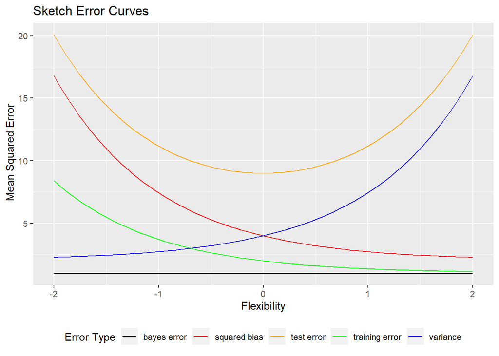

```r
library(ggplot2)
flexibility <- seq(-2, 2, length.out = 100)
squared_bias <- 2*exp(-flexibility) + 2
variance <- 2*exp(flexibility) + 2
training_error <- squared_bias*.5
bayes_error <- 1
test_error <- squared_bias + variance + bayes_error

ggplot() +
  geom_line(aes(x = flexibility, y = squared_bias, color = "squared bias")) +
  geom_line(aes(x = flexibility, y = variance, color = "variance")) +
  geom_line(aes(x = flexibility, y = training_error, color = "training error")) +
  geom_line(aes(x = flexibility, y = test_error, color = "test error")) +
  geom_line(aes(x = flexibility, y = bayes_error, color = "bayes error")) +
  labs(x = "Flexibility", y = " Mean Squared Error", color = "Error Type") +
  scale_color_manual(values = c("squared bias" = "red", "variance" = "blue", "training error" = "green", "test error" = "orange", "irreducible error" = "purple", "bayes error" = "black")) +
  theme(legend.position = "bottom")+
  labs(title = "Sketch Error Curves")
```

(b) Explain why each of the five curves has the shape displayed in part (a).

**Answer:** Bayes error (irreducible error) is flat because it is a constant and represents the lowest possible error of any model, which is the noise inherent in the dataset, thus it is not affected by the flexibility of the model and is lowest of any error.

The variance generally increases as model flexibility increases. This is because a more flexible model is more sensitive to the training data and will change more if the training data changes. A complex model would have high variance as they react to minor fluctuations in the training data.

The training error typically decreases as model flexibility increases because a more flexible model will fit the training data better. However, this may not translate to better test performance due to overfitting.

## 3 ISL Exercise 2.4.4 (10pts)

(a) Describe three real-life applications in which classification might be useful. Describe the response, as well as the predictors. Is the goal of each application inference or prediction? Explain your answer.

**Answer:**

One such useful application could be detecting phishing emails, then the user can be protected from phishing scams with email. The response variable would be the classification of whether said incoming email is either belonging in the category of “Phish” or “Not Phish”. The predictors could include email address, email content, attachments or other metadata of said email. The goal of this application is prediction, the model will predict the probability of said email being phish given the predictors.

Another useful application could be image recognition in autonomous vehicles. In autonomous driving, it involves classification with identifying the object in the camera of the vehicle to make the next decision. The response variable would be class labels of learned objects like other cars, trees, wall, pedestrian etc. The predictors could be pixels RGB values captured by the sensors or cameras. The goal for this particular purpose is prediction, where the model will predict the object in the surroundings captured by the sensors to make the next decision for autonomous driving purposes.

Third application could be diagnosis of diseases, this could report a specific possible disease given predictors. The response variable would be the probability of a medical condition and inferred presence of said condition. The predictors could be the symptoms and the medical history of the patient etc. The goal of this model would involve both inference and prediction, where predictions is involved with determining the probability of a disease and an inference would be made about the presence of that disease in the patient.

(b) Describe three real-life applications in which regression might be useful. Describe the response, as well as the predictors. Is the goal of each application inference or prediction? Explain your answer.

**Answer:**

One application could be temperature prediction. The response would be temperature. The predictors would be variables like wind speed, air pressure, humidity and geographical locations etc. The goal of this model would be to predict the temperature given the predictors.

Another possible application could be in research like risk factors of lung cancer. The response variable would be probability of lung cancer, while predictors could be the number of cigarette smoked per week, diet, exercise etc. The goal of this model would be inference using regression analysis to infer the relationships between different predictors and the probability of developing the lung cancer.

Another application could be productivity in the workplace. The response variable would be the productivity level of employees. The predictors could be job satisfaction, income pay, work hours etc. The goal of the model would be inference, to infer the relationship different predictors effects on employee productivity.

(c) Describe three real-life applications in which cluster analysis might be useful.

**Answer:**

One application could be healthcare patient segmentation. Personalized healthcare interventions can be developed for each patient segment based on the health indicators, medical history etc. The patient outcome could be greatly improved with the tailored treatment approach.

Another application could be anomaly detection. The goal of this model could be to identify unusual patterns in the data that do not conform to expected behavior. This could be useful in identifying outliers in data which is crucial in fraud detection, network security and quality control etc.

Third application could be in genomic research where researchers use cluster analysis to group genes or proteins with similar expression patterns. This could be useful in identifying genes or proteins that are co-regulated or co-expressed. This helps in understanding the biological functions of genes and proteins, genetic relations and drug development etc.

## 4 ISL Exercise 2.4.10 (30pts)

Your can read in the `boston` data set directly from url https://raw.githubusercontent.com/ucla-biostat-212a/2024winter/master/slides/data/Boston.csv. A documentation of the `boston` data set is [here](https://www.rdocumentation.org/packages/ISLR2/versions/1.3-2/topics/Boston).

```r
library(tidyverse)
Boston <- read_csv("https://raw.githubusercontent.com/ucla-biostat-212a/2024winter/master/slides/data/Boston.csv", col_select = -1) %>%
  print(width = Inf)
```

```
# A tibble: 506 × 13
      crim    zn indus  chas   nox    rm   age   dis   rad   tax ptratio lstat
     <dbl> <dbl> <dbl> <dbl> <dbl> <dbl> <dbl> <dbl> <dbl> <dbl>   <dbl> <dbl>
 1 0.00632  18    2.31     0 0.538  6.58  65.2  4.09     1   296    15.3  4.98
 2 0.0273    0    7.07     0 0.469  6.42  78.9  4.97     2   242    17.8  9.14
 3 0.0273    0    7.07     0 0.469  7.18  61.1  4.97     2   242    17.8  4.03
 4 0.0324    0    2.18     0 0.458  7.00  45.8  6.06     3   222    18.7  2.94
 5 0.0690    0    2.18     0 0.458  7.15  54.2  6.06     3   222    18.7  5.33
 6 0.0298    0    2.18     0 0.458  6.43  58.7  6.06     3   222    18.7  5.21
 7 0.0883   12.5  7.87     0 0.524  6.01  66.6  5.56     5   311    15.2 12.4
 8 0.145    12.5  7.87     0 0.524  6.17  96.1  5.95     5   311    15.2 19.2
 9 0.211    12.5  7.87     0 0.524  5.63 100    6.08     5   311    15.2 29.9
10 0.170    12.5  7.87     0 0.524  6.00  85.9  6.59     5   311    15.2 17.1
    medv
   <dbl>
 1  24
 2  21.6
 3  34.7
 4  33.4
 5  36.2
 6  28.7
 7  22.9
 8  27.1
 9  16.5
10  18.9
# ℹ 496 more rows
```

(a)How many rows are in this data set? How many columns? What do the rows and columns represent?

(b) Make some pairwise scatterplots of the predictors (columns) in this data set. Describe your findings.

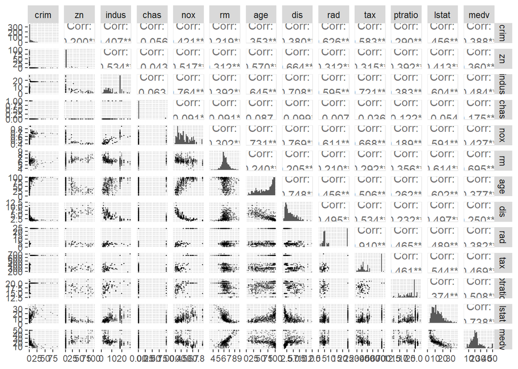

```r
library(tidyverse)
library(GGally)
Bostonpairs=ggpairs(data=Boston, lower = list(continuous = wrap("points", alpha = 0.3, size=0.2)), diag=list(continuous='barDiag'))
Bostonpairs
```

**Answer:** There is a strong positive correlation between the number of rooms (`rm`) and the median value of owner-occupied homes (`medv`), with a correlation coefficient of 0.695.This suggests that as the number of rooms (a larger house) tend to be more valuable which is intuitive. The accessibility to radical highways (`rad`) is also highly positively correlated with the index of accessibility to radial highways (`tax`), with a correlation coefficient of 0.910. This suggests that the suburbs with more accessibility to radial highways tend to have higher tax rates.

There is a strong negative correlation between the percentage of lower status of the population (`lstat`) and the median value of owner-occupied homes (`medv`). This suggests that the suburbs with a higher percentage of lower status of the population tend to have lower median value of owner-occupied homes. There is a strong negative correlation between the pupil-teacher ratio by town (`ptratio`) and the median value of owner-occupied homes (`medv`). This suggests that the suburbs with a higher pupil-teacher ratio tend to have lower median value of owner-occupied homes.

The `chas` variable is a binary variable with 1 indicating that the suburb is bound by the Charles River and 0 otherwise. The `chas` variable is not highly correlated with any other variables, which is expected since it is a binary variable representing a categorical variable.

The histograms along the diagonal show the distribution of each variable. For instance, `crim` (per capita crime rate by town) and `zn` (proportion of residential land zoned for lots over 25,000 sq.ft.) are right-skewed, indicating that most towns have low crime rates and are not predominantly zoned for large residential lots.

Several variables display potential outliers. For example, `crim` has some towns with very high crime rates compared to the majority, and `tax` shows some towns with unusually high tax rates.

(c)Are any of the predictors associated with per capita crime rate? If so, explain the relationship.

**Answer:** `crim` is positively associated with `rad`, `tax`, `ptratio`, and `lstat`. This suggests that the suburbs with more accessibility to radial highways, higher tax rates, higher pupil-teacher ratio, and higher percentage of lower status of the population tend to have higher crime rates.

(d) Do any of the census tracts of Boston appear to have particularly high crime rates? Tax rates? Pupil-teacher ratios? Comment on the range of each predictor.

**Answer:** The density distribution of `crim` is positively skewed with the tail in the positive direction, which indicates that the majority of the data points are clustered in the lower end of the scale infering that crime rates are typically low. However we can see few census tracts dotted on the higher end, indicating that there is census tracts with higher crime rate. Thus in general, crime rates are usually low but there are some areas with particularly high crime rates. The super high peaks indicates high variability, but since range represents the presence of extreme values and not the density of those values, `crim` predictor has a large range since there are presence of both extreme values.

The density distribution of `tax` looked normal at large on the lower end of the plot, where there is an increasing occurances as higher taxes to a certain point and taxes occurances dropped further after that point as taxes increases. However there is a high occurance of high taxes on the right end. The two peaks suggests that there are common tax rates that many tracts share with low or high tax rates, and the gap between these peaks indicate fewer tracts with intermediate tax rates. As a whole, I would say that the distribution of `tax` is multimodal, thus there could be distinct subgroups within the `tax` data. Since the start point and end point of the histogram is far apart, I am inclined to say that the range of `tax` is large but with variability.

The distribution of `ptratio` is relatively uniform compared to `crime` or `tax`, but there are still a high density of census tracks with notably high pupil-teacher ratios, which can be inferred from the data points towards the upper end of the histogram. Based on the visual representation of the histogram, the range of `ptratio` is pretty large as the width of the distribution is long and the data is spread out and evenly distributed. Just by looking at the scatter plot, `ptratio` predictor would have a large range since there are presence of both extreme values.

(e) How many of the census tracts in this data set bound the Charles river?

**Answer:** Based on the scatter plot, there are far fewer census tracts that bound thhe charles river than those that do not. We can get the exact amount with the following code.

```r
# since chas is a binary variable, we can sum the number of 1s to get the number of census tracts that bound the Charles river
sum(Boston$chas)
```

```
[1] 35
```

There are 35 census tracts that bound the Charles river.

(f) What is the median pupil-teacher ratio among the towns in this data set?

**Answer:** We can get the median pupil-teacher ratio among the towns in this data set with the following code.

```r
median(Boston$ptratio)
```

```
[1] 19.05
```

The median pupil-teacher ratio among the towns in this data set is 19.05.

(g) Which census tract of Boston has lowest median value of owner-occupied homes? What are the values of the other predictors for that census tract, and how do those values compare to the overall ranges for those predictors? Comment on your findings.

**Answer:** We can get the census tract of Boston with the lowest median value of owner-occupied homes with the following code. The other values are also displayed .

```r
library(ggplot2)
library(reshape2)
library(dplyr)

# Identify the tract with the lowest median home value
min_medv_row = Boston[which.min(Boston$medv), ]
print(min_medv_row)
```

```
# A tibble: 1 × 13
   crim    zn indus  chas   nox    rm   age   dis   rad   tax ptratio lstat
  <dbl> <dbl> <dbl> <dbl> <dbl> <dbl> <dbl> <dbl> <dbl> <dbl>   <dbl> <dbl>
1  38.4     0  18.1     0 0.693  5.45   100  1.49    24   666    20.2  30.6
# ℹ 1 more variable: medv <dbl>
```

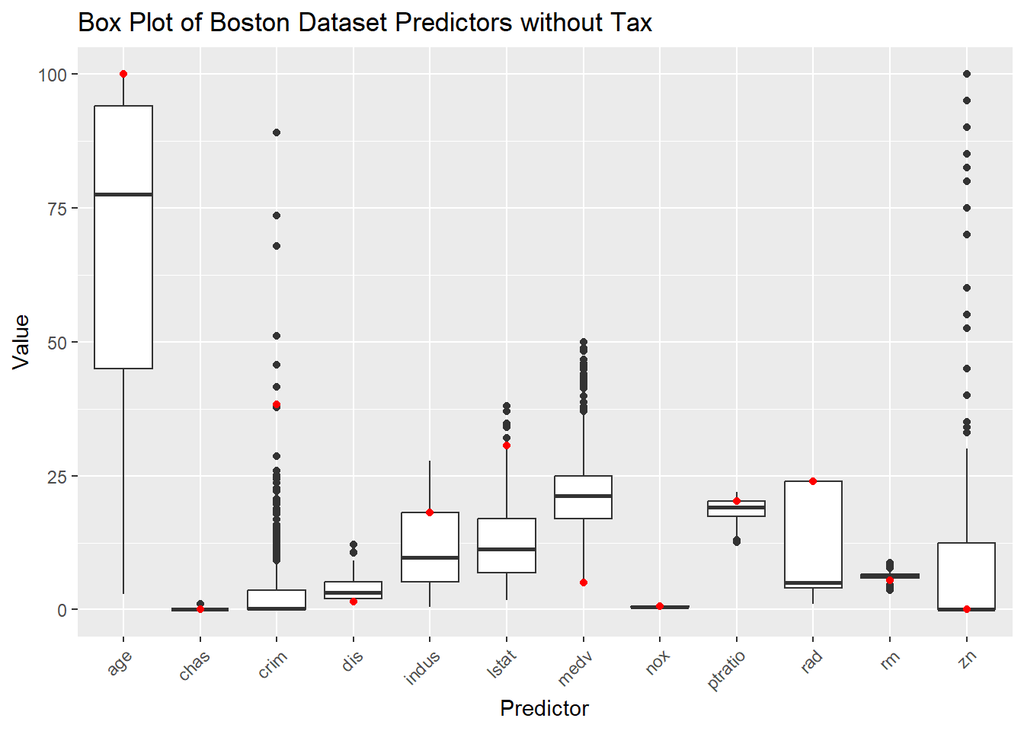

```r
# Tax has a larger range than the other predictors, so we will exclude it from the boxplots to show on a separate plot so that we can see the other predictors more clearly.

# Convert the Boston dataset to a long format excluding `tax`
long_boston_without_tax = Boston %>%
  select(-tax) %>%
  pivot_longer(cols = everything(), names_to = "Predictor", values_to = "Value")

# Convert the specific tract values to a long format excluding `tax`
specific_tract_without_tax = min_medv_row %>%
  select(-tax) %>%
  pivot_longer(cols = everything(), names_to = "Predictor", values_to = "Value")

# Plot for all predictors except `tax`
ggplot(long_boston_without_tax, aes(x = Predictor, y = Value)) +
  geom_boxplot() +
  geom_point(data = specific_tract_without_tax, aes(x = Predictor, y = Value), color = "red") +
  theme(axis.text.x = element_text(angle = 45, hjust = 1)) +
  labs(title = "Box Plot of Boston Dataset Predictors without Tax")
```

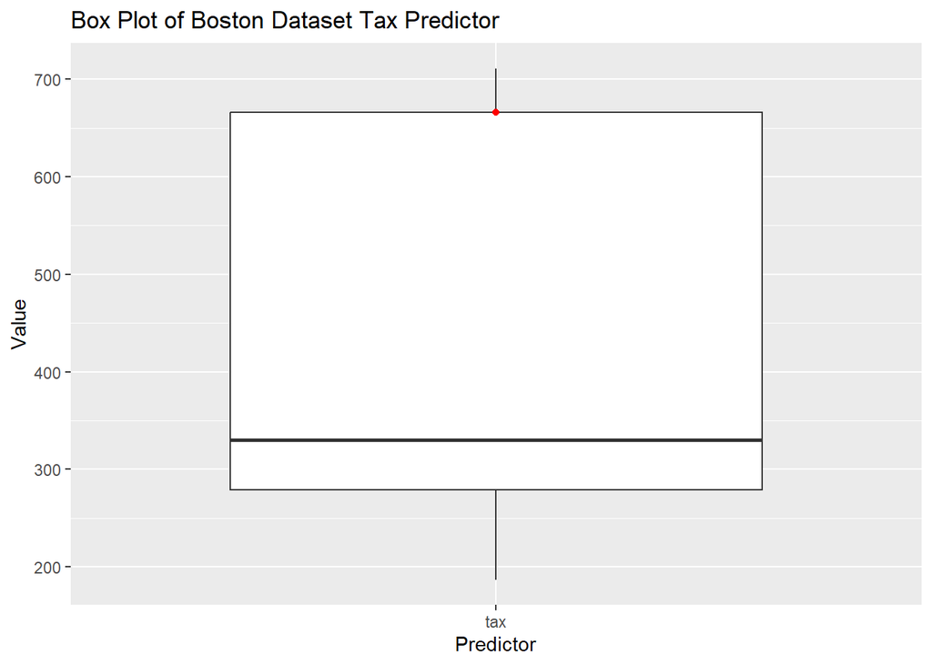

```r
# Convert the `tax` data to long format
long_boston_tax = Boston %>%
  select(tax) %>%
  pivot_longer(cols = everything(), names_to = "Predictor", values_to = "Value")

# Convert the specific tract `tax` value to long format
specific_tract_tax = min_medv_row %>%
  select(tax) %>%
  pivot_longer(cols = everything(), names_to = "Predictor", values_to = "Value")

# Plot only for `tax`
ggplot(long_boston_tax, aes(x = Predictor, y = Value)) +
  geom_boxplot() +
  geom_point(data = specific_tract_tax, aes(x = Predictor, y = Value), color = "red") +
  labs(title = "Box Plot of Boston Dataset Tax Predictor")
```

The `age` in the specific tract is at the top of the whiskers which indicates that it has older (could be oldest) buildings compared to the other tracts.

Since `chas` a binary variable, the box plot isn’t particularly informative. The specific tract does not border the Charles River.

The specific tract has high `crim` which would be considered an outlier.

The `dis` value lies lower than the median and close to the lower quartile suggesting that it is closer to employment center than other tracts.

The `indus` value is close to the third quartile which suggest that the tract has a high proportion of non-retail business acres per town than many other tracts.

The value for `lstat` is very high in this tract, way above the third quartile which suggests that there is a higher percentage of lower status of the population in this tract.

As we know that this tract is the lowest `medv` in Boston.

The `nox` values seems to be above the median which indicates a higher nitrogen oxides concentration in this tract.

The pupil-teacher ratio (`ptratio`) is at the upper quartile but within the interquartile range, indicating a higher than average ratio.

Accessibility to radial highways (`rad`) is at the third quartile for this tract, indicates that it has higher accessibility to radial highways than other tracts.

The average number of rooms per dwelling (`rm`) is below the median, suggesting smaller dwelling sizes in this tract.

The proportion of residential land zoned for lots over 25,000 (`zn`) square feet is at the median, which is common in the dataset.

`tax` is at the upper quartile, indicating that this tract has a higher tax rate than other tracts.

(h) In this data set, how many of the census tracts average more than seven rooms per dwelling? More than eight rooms per dwelling? Comment on the census tracts that average more than eight rooms per dwelling.

**Answer:**

```r
library(ggplot2)
library(dplyr)
# Number of census tracts that average more than seven rooms per dwelling
sum(Boston$rm > 7)
```

```
[1] 64
```

```r
# more than 8
sum(Boston$rm > 8)
```

```
[1] 13
```

```r
# Comment on the census tracts that average more than eight rooms per dwelling
tract = Boston[Boston$rm > 8, ]
tract
```

```
# A tibble: 13 × 13
     crim    zn indus  chas   nox    rm   age   dis   rad   tax ptratio lstat
    <dbl> <dbl> <dbl> <dbl> <dbl> <dbl> <dbl> <dbl> <dbl> <dbl>   <dbl> <dbl>
 1 0.121      0  2.89     0 0.445  8.07  76    3.50     2   276    18    4.21
 2 1.52       0 19.6      1 0.605  8.38  93.9  2.16     5   403    14.7  3.32
 3 0.0201    95  2.68     0 0.416  8.03  31.9  5.12     4   224    14.7  2.88
 4 0.315      0  6.2      0 0.504  8.27  78.3  2.89     8   307    17.4  4.14
 5 0.527      0  6.2      0 0.504  8.72  83    2.89     8   307    17.4  4.63
 6 0.382      0  6.2      0 0.504  8.04  86.5  3.22     8   307    17.4  3.13
 7 0.575      0  6.2      0 0.507  8.34  73.3  3.84     8   307    17.4  2.47
 8 0.331      0  6.2      0 0.507  8.25  70.4  3.65     8   307    17.4  3.95
 9 0.369     22  5.86     0 0.431  8.26   8.4  8.91     7   330    19.1  3.54
10 0.612     20  3.97     0 0.647  8.70  86.9  1.80     5   264    13    5.12
11 0.520     20  3.97     0 0.647  8.40  91.5  2.29     5   264    13    5.91
12 0.578     20  3.97     0 0.575  8.30  67    2.42     5   264    13    7.44
13 3.47       0 18.1      1 0.718  8.78  82.9  1.90    24   666    20.2  5.29
# ℹ 1 more variable: medv <dbl>
```

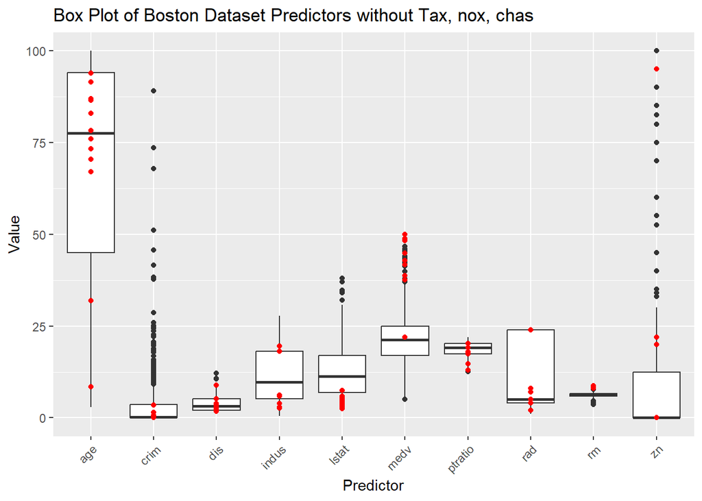

```r
#Since a couple of the predictors have a large/small range, we will exclude them from the boxplots to show on a separate plot so that we can see the other predictors more clearly.

# Convert the Boston dataset to a long format excluding `tax`, `chas`, `nox`
long_boston_without_tax = Boston %>%
  select(-c(tax, chas, nox)) %>%
  pivot_longer(cols = everything(), names_to = "Predictor", values_to = "Value")

# Convert the specific tract values to a long format excluding `tax`, `chas`, `nox`
tract_without_tax = tract %>%
  select(-c(tax, chas, nox)) %>%
  pivot_longer(cols = everything(), names_to = "Predictor", values_to = "Value")

# Plot for all predictors except `tax`, `chas`, `nox`
ggplot(long_boston_without_tax, aes(x = Predictor, y = Value)) +
  geom_boxplot() +
  geom_point(data = tract_without_tax, aes(x = Predictor, y = Value), color = "red") +
  theme(axis.text.x = element_text(angle = 45, hjust = 1)) +
  labs(title = "Box Plot of Boston Dataset Predictors without Tax, nox, chas")
```

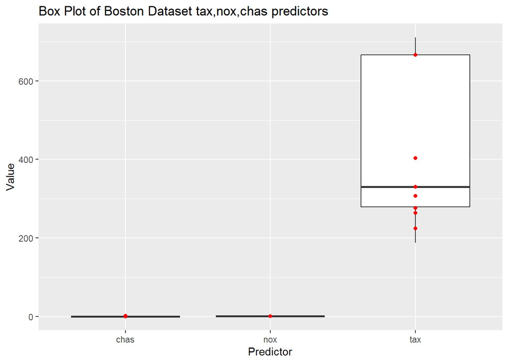

```r
# Convert the `tax`, `chas`, `nox` data to long format
long_boston_tax = Boston %>%
  select(c(tax, chas, nox)) %>%
  pivot_longer(cols = everything(), names_to = "Predictor", values_to = "Value")

# Convert the specific tract `tax`, `chas`, `nox` values to long format
tract_tax = tract %>%
  select(c(tax, chas, nox)) %>%
  pivot_longer(cols = everything(), names_to = "Predictor", values_to = "Value")

# Plot only for `tax`, `chas`, `nox`
ggplot(long_boston_tax, aes(x = Predictor, y = Value)) +
  geom_boxplot() +
  geom_point(data = tract_tax, aes(x = Predictor, y = Value), color = "red") +
  labs(title = "Box Plot of Boston Dataset tax,nox,chas predictors")
```

Notably there are only 13 census tracts that average more than eight rooms per dwelling. The red dots reflects the 13 tracts and their respective values for each predictors.

`indus` values have the majority below the median, with exception to two of them. `lstat` values are all below the median. `tax` values are all below the median, except for two tracts. These values suggests that larger property tend to lower proportion of non-retail business acres per town, have higher status of the population, and have lower tax rates.

`medv` values are all above the median, with exception to one tract, suggesting that tracts with more than 8 rooms per dwelling tend to have higher median value of owner-occupied homes.

`age`, `dis`, `ptratio` and `zn` predictor values are pretty spread out suggesting that they are not really co-related with having more rooms per dwelling.

`crim` values are not in the outliers region, suggesting that tracts with more rooms per dwelling do not have particularly high crime rates. `rad` values are about the median, suggesting that tracts with more than 8 rooms per dwelling have average accessibility to radial highways.

## 5 ISL Exercise 3.7.3 (12pts)

Suppose we have a data set with five predictors, X1 = GPA, X2 = IQ, X3 = Level (1 for College and 0 for High School), X4 = Interaction between GPA and IQ, and X5 = Interaction between GPA and Level. The response is starting salary after graduation (in thousands of dollars). Suppose we use least squares to fit the model, and get $\hat{\beta}_0 = 50, \hat{\beta}_1 = 20, \hat{\beta}_2 = 0.07, \hat{\beta}_3 = 35, \hat{\beta}_4 = 0.01, \hat{\beta}_5 = −10$.

(a) Which answer is correct, and why? i. For a fixed value of IQ and GPA, high school graduates earn more, on average, than college graduates.

**Answer:** Incorrect, since the coefficient for `level` ($\hat{\beta}_3 = 35$) is positive, this suggests that college graduates earn more than high school graduates.

2. For a fixed value of IQ and GPA, college graduates earn more, on average, than high school graduates.

**Answer:** Correct, since the coefficient for `level` ($\hat{\beta}_3 = 35$) is positive, this suggests that college graduates earn more than high school graduates by 35 thousand per increase in level (from high school to college).

3. For a fixed value of IQ and GPA, high school graduates earn more, on average, than college graduates provided that the GPA is high enough.

4. For a fixed value of IQ and GPA, college graduates earn more, on average, than high school graduates provided that the GPA is high enough.

(b) Predict the salary of a college graduate with IQ of 110 and a GPA of 4.0.

**Answer:** We can predict the salary of a college graduate with IQ of 110 and a GPA of 4.0 by plugging the values into the equation.

$$\begin{align*}
\hat{y} &= \hat{\beta}_0 + \hat{\beta}_1x_1 + \hat{\beta}_2x_2 + \hat{\beta}_3x_3 + \hat{\beta}_4x_4 + \hat{\beta}_5x_5 \\
\hat{y} &= 50 + 20(4.0) + 0.07(110) + 35(1) + 0.01(4.0)(110) + (-10)(4.0)(1)\\
\hat{y} &= 137.1 \text{ (In thousands)}
\end{align*}$$
(c) True or false: Since the coefficient for the GPA/IQ interaction term is very small, there is very little evidence of an interaction effect. Justify your answer.

**Answer:** False, the coefficient for the GPA/IQ interaction term being small does not mean that there is very little evidence of an interaction effect. The coefficient for the GPA/IQ interaction term being small only means that the effect of the interaction between GPA and IQ is small, but it does not mean that there is no interaction effect. The interaction effect is still present, but it is small. The evidence of interaction effect would require hypothesis testing and conclude based on the p-value and chosen significance level.

## 6 ISL Exercise 3.7.15 (20pts)

This problem involves the Boston data set, which we saw in the lab for this chapter. We will now try to predict per capita crime rate using the other variables in this data set. In other words, per capita crime rate is the response, and the other variables are the predictors.

(a) For each predictor, fit a simple linear regression model to predict the response. Describe your results. In which of the models is there a statistically significant association between the predictor and the response? Create some plots to back up your assertions.

**Answer:**

```r
znmodel = lm(crim ~ zn, data = Boston)
summary(znmodel)
```

```
Call:
lm(formula = crim ~ zn, data = Boston)

Residuals:
   Min     1Q Median     3Q    Max
-4.429 -4.222 -2.620  1.250 84.523

Coefficients:
            Estimate Std. Error t value Pr(>|t|)
(Intercept)  4.45369    0.41722  10.675  < 2e-16 ***
zn          -0.07393    0.01609  -4.594 5.51e-06 ***
---
Signif. codes:  0 '***' 0.001 '**' 0.01 '*' 0.05 '.' 0.1 ' ' 1

Residual standard error: 8.435 on 504 degrees of freedom
Multiple R-squared:  0.04019,   Adjusted R-squared:  0.03828
F-statistic:  21.1 on 1 and 504 DF,  p-value: 5.506e-06
```

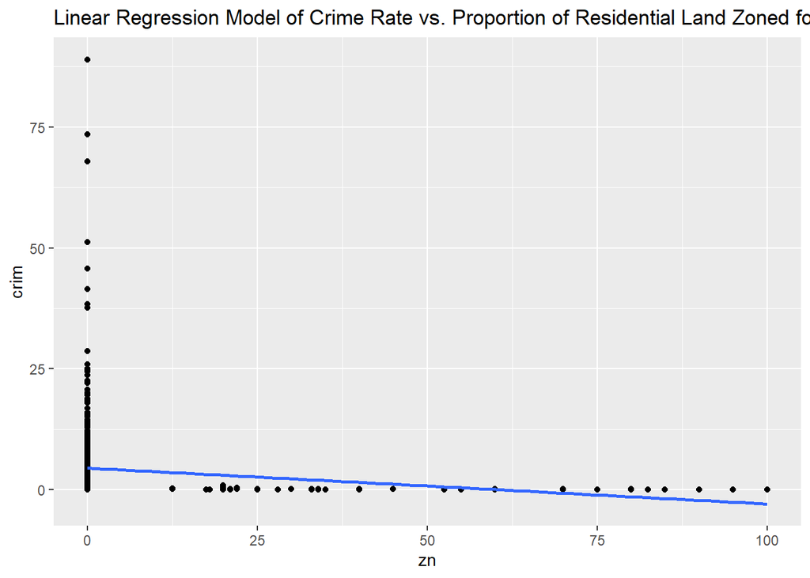

```r
ggplot(znmodel, aes(x = zn, y = crim)) +
  geom_point() +
  geom_smooth(method = "lm", se = FALSE) +
  labs(title = "Linear Regression Model of Crime Rate vs. Proportion of Residential Land Zoned for Lots over 25,000 sq.ft.")
```

```r
indusmodel = lm(crim ~ indus, data = Boston)
summary(indusmodel)
```

```
Call:
lm(formula = crim ~ indus, data = Boston)

Residuals:
    Min      1Q  Median      3Q     Max
-11.972  -2.698  -0.736   0.712  81.813

Coefficients:
            Estimate Std. Error t value Pr(>|t|)
(Intercept) -2.06374    0.66723  -3.093  0.00209 **
indus        0.50978    0.05102   9.991  < 2e-16 ***
---
Signif. codes:  0 '***' 0.001 '**' 0.01 '*' 0.05 '.' 0.1 ' ' 1

Residual standard error: 7.866 on 504 degrees of freedom
Multiple R-squared:  0.1653,    Adjusted R-squared:  0.1637
F-statistic: 99.82 on 1 and 504 DF,  p-value: < 2.2e-16
```

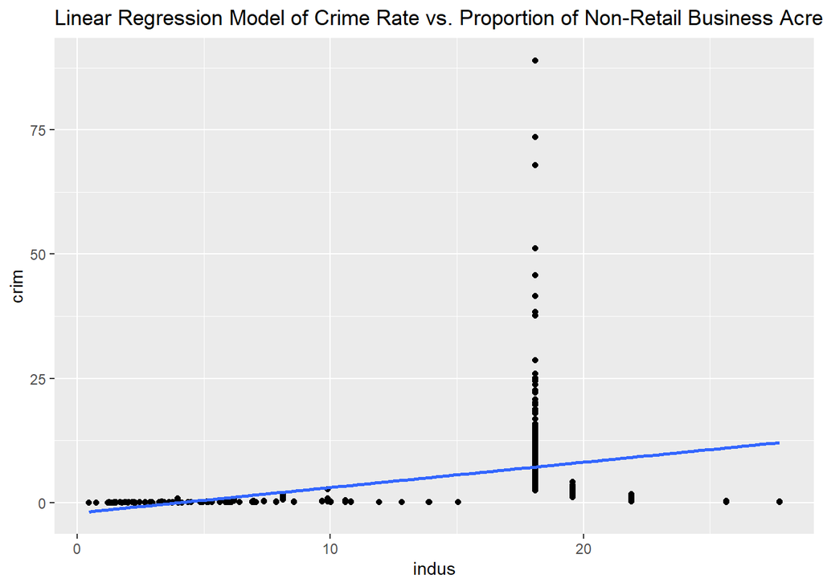

```r
ggplot(indusmodel, aes(x = indus, y = crim)) +
  geom_point() +
  geom_smooth(method = "lm", se = FALSE) +
  labs(title = "Linear Regression Model of Crime Rate vs. Proportion of Non-Retail Business Acres per Town")
```

```r
chasmodel = lm(crim ~ chas, data = Boston)
summary(chasmodel)
```

```
Call:
lm(formula = crim ~ chas, data = Boston)

Residuals:
   Min     1Q Median     3Q    Max
-3.738 -3.661 -3.435  0.018 85.232

Coefficients:
            Estimate Std. Error t value Pr(>|t|)
(Intercept)   3.7444     0.3961   9.453   <2e-16 ***
chas         -1.8928     1.5061  -1.257    0.209
---
Signif. codes:  0 '***' 0.001 '**' 0.01 '*' 0.05 '.' 0.1 ' ' 1

Residual standard error: 8.597 on 504 degrees of freedom
Multiple R-squared:  0.003124,  Adjusted R-squared:  0.001146
F-statistic: 1.579 on 1 and 504 DF,  p-value: 0.2094
```

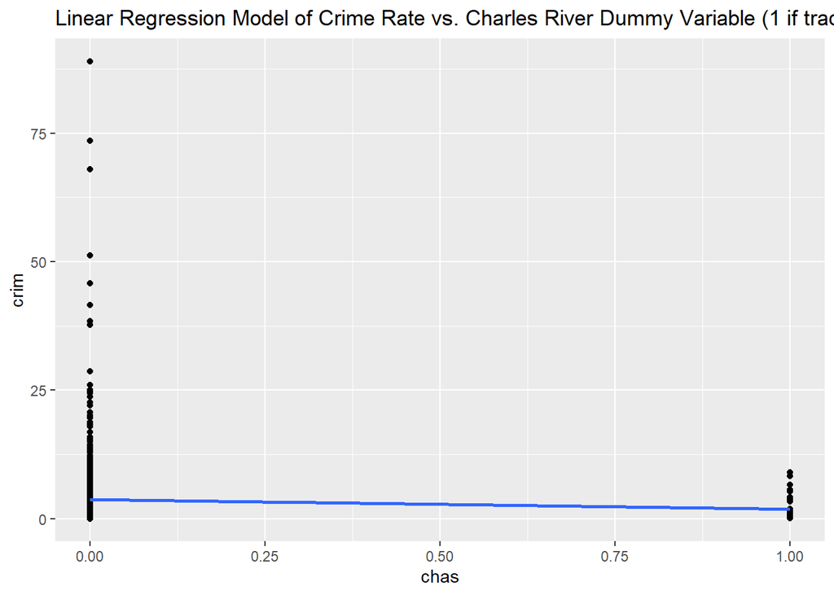

```r
ggplot(chasmodel, aes(x = chas, y = crim)) +
  geom_point() +
  geom_smooth(method = "lm", se = FALSE) +
  labs(title = "Linear Regression Model of Crime Rate vs. Charles River Dummy Variable (1 if tract bounds river; 0 otherwise)")
```

```r
noxmodel = lm(crim ~ nox, data = Boston)
summary(noxmodel)
```

```
Call:
lm(formula = crim ~ nox, data = Boston)

Residuals:
    Min      1Q  Median      3Q     Max
-12.371  -2.738  -0.974   0.559  81.728

Coefficients:
            Estimate Std. Error t value Pr(>|t|)
(Intercept)  -13.720      1.699  -8.073 5.08e-15 ***
nox           31.249      2.999  10.419  < 2e-16 ***
---
Signif. codes:  0 '***' 0.001 '**' 0.01 '*' 0.05 '.' 0.1 ' ' 1

Residual standard error: 7.81 on 504 degrees of freedom
Multiple R-squared:  0.1772,    Adjusted R-squared:  0.1756
F-statistic: 108.6 on 1 and 504 DF,  p-value: < 2.2e-16
```

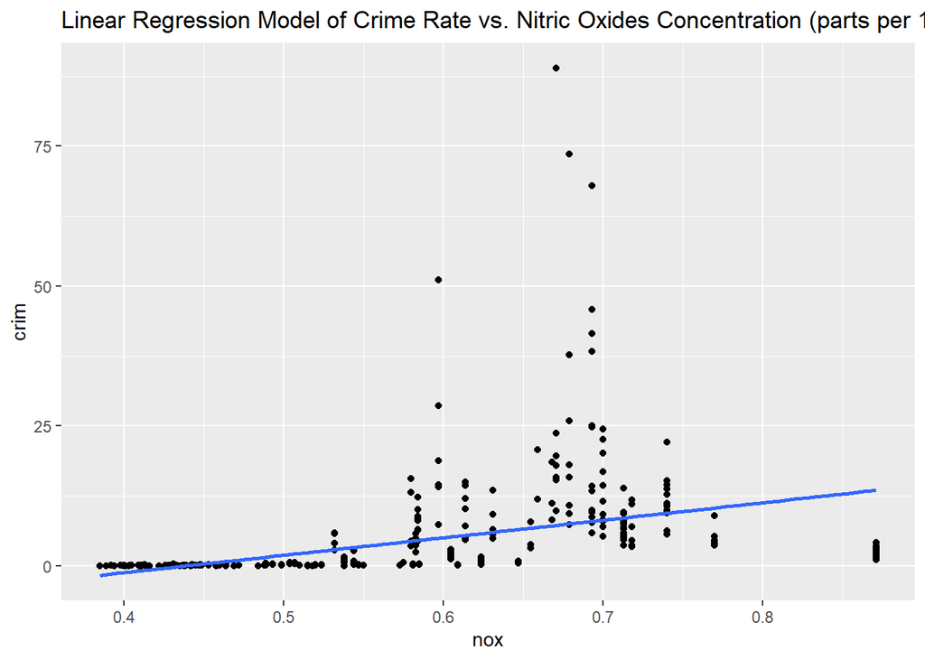

```r
ggplot(noxmodel, aes(x = nox, y = crim)) +
  geom_point() +
  geom_smooth(method = "lm", se = FALSE) +
  labs(title = "Linear Regression Model of Crime Rate vs. Nitric Oxides Concentration (parts per 10 million)")
```

```r
rmmodel = lm(crim ~ rm, data = Boston)
summary(rmmodel)
```

```
Call:
lm(formula = crim ~ rm, data = Boston)

Residuals:
   Min     1Q Median     3Q    Max
-6.604 -3.952 -2.654  0.989 87.197

Coefficients:
            Estimate Std. Error t value Pr(>|t|)
(Intercept)   20.482      3.365   6.088 2.27e-09 ***
rm            -2.684      0.532  -5.045 6.35e-07 ***
---
Signif. codes:  0 '***' 0.001 '**' 0.01 '*' 0.05 '.' 0.1 ' ' 1

Residual standard error: 8.401 on 504 degrees of freedom
Multiple R-squared:  0.04807,   Adjusted R-squared:  0.04618
F-statistic: 25.45 on 1 and 504 DF,  p-value: 6.347e-07
```

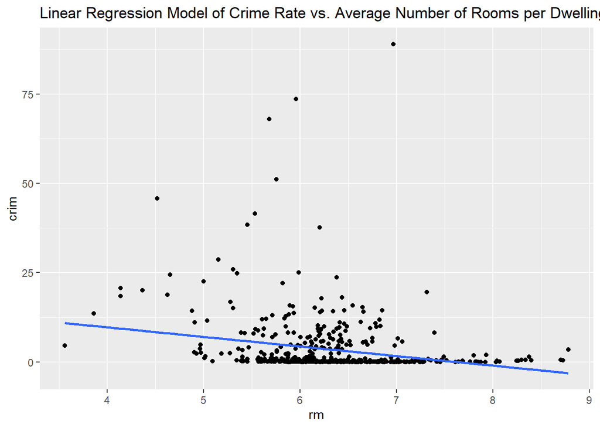

```r
ggplot(rmmodel, aes(x = rm, y = crim)) +
  geom_point() +
  geom_smooth(method = "lm", se = FALSE) +
  labs(title = "Linear Regression Model of Crime Rate vs. Average Number of Rooms per Dwelling")
```

```r
agemodel = lm(crim ~ age, data = Boston)
summary(agemodel)
```

```
Call:
lm(formula = crim ~ age, data = Boston)

Residuals:
   Min     1Q Median     3Q    Max
-6.789 -4.257 -1.230  1.527 82.849

Coefficients:
            Estimate Std. Error t value Pr(>|t|)
(Intercept) -3.77791    0.94398  -4.002 7.22e-05 ***
age          0.10779    0.01274   8.463 2.85e-16 ***
---
Signif. codes:  0 '***' 0.001 '**' 0.01 '*' 0.05 '.' 0.1 ' ' 1

Residual standard error: 8.057 on 504 degrees of freedom
Multiple R-squared:  0.1244,    Adjusted R-squared:  0.1227
F-statistic: 71.62 on 1 and 504 DF,  p-value: 2.855e-16
```

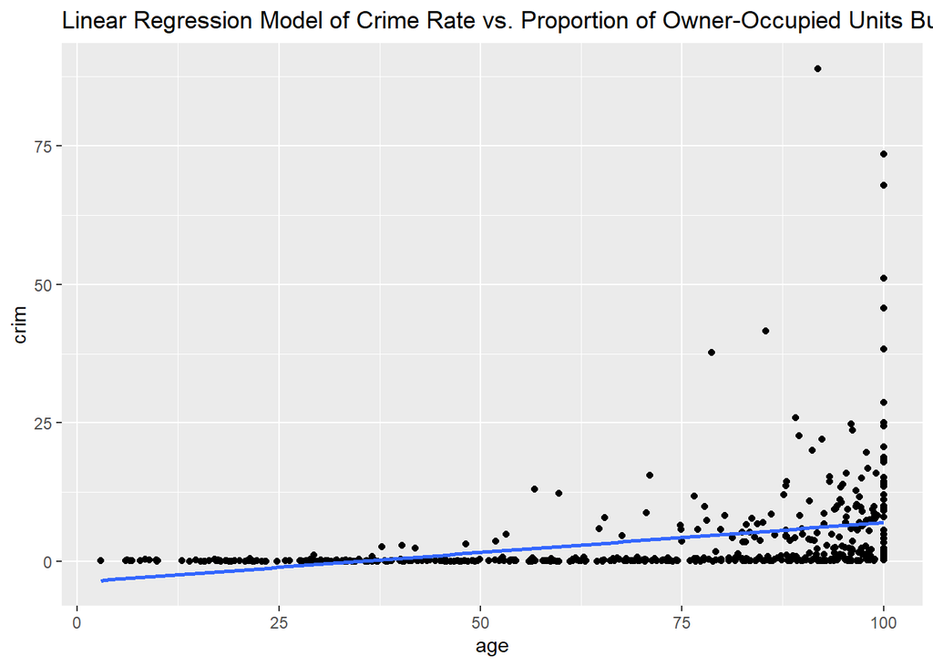

```r
ggplot(agemodel, aes(x = age, y = crim)) +
  geom_point() +
  geom_smooth(method = "lm", se = FALSE) +
  labs(title = "Linear Regression Model of Crime Rate vs. Proportion of Owner-Occupied Units Built Prior to 1940")
```

```r
dismodel = lm(crim ~ dis, data = Boston)
summary(dismodel)
```

```
Call:
lm(formula = crim ~ dis, data = Boston)

Residuals:
   Min     1Q Median     3Q    Max
-6.708 -4.134 -1.527  1.516 81.674

Coefficients:
            Estimate Std. Error t value Pr(>|t|)
(Intercept)   9.4993     0.7304  13.006   <2e-16 ***
dis          -1.5509     0.1683  -9.213   <2e-16 ***
---
Signif. codes:  0 '***' 0.001 '**' 0.01 '*' 0.05 '.' 0.1 ' ' 1

Residual standard error: 7.965 on 504 degrees of freedom
Multiple R-squared:  0.1441,    Adjusted R-squared:  0.1425
F-statistic: 84.89 on 1 and 504 DF,  p-value: < 2.2e-16
```

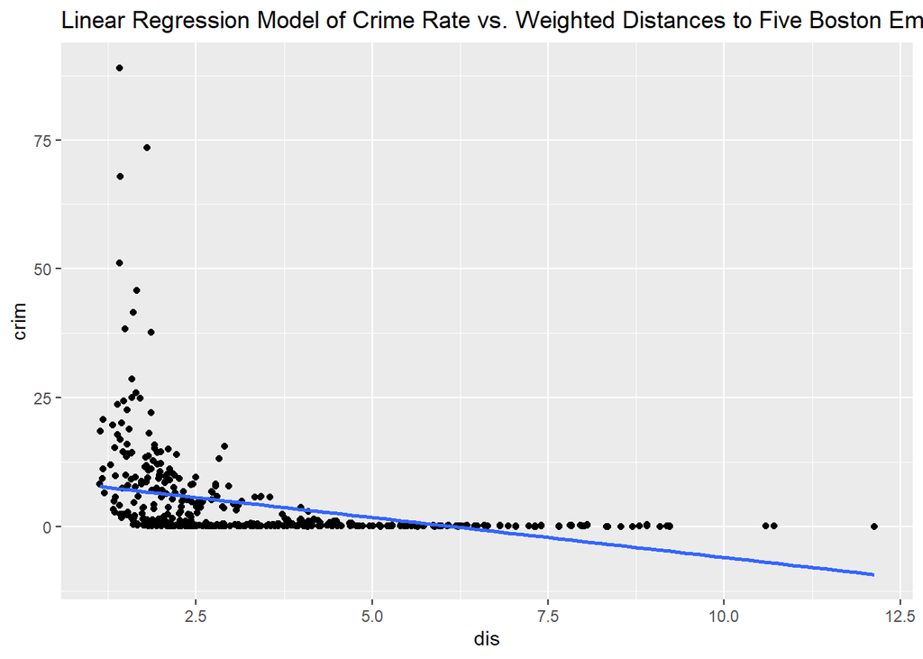

```r
ggplot(dismodel, aes(x = dis, y = crim)) +
  geom_point() +
  geom_smooth(method = "lm", se = FALSE) +
  labs(title = "Linear Regression Model of Crime Rate vs. Weighted Distances to Five Boston Employment Centres")
```

```r
radmodel = lm(crim ~ rad, data = Boston)
summary(radmodel)
```

```
Call:
lm(formula = crim ~ rad, data = Boston)

Residuals:
    Min      1Q  Median      3Q     Max
-10.164  -1.381  -0.141   0.660  76.433

Coefficients:
            Estimate Std. Error t value Pr(>|t|)
(Intercept) -2.28716    0.44348  -5.157 3.61e-07 ***
rad          0.61791    0.03433  17.998  < 2e-16 ***
---
Signif. codes:  0 '***' 0.001 '**' 0.01 '*' 0.05 '.' 0.1 ' ' 1

Residual standard error: 6.718 on 504 degrees of freedom
Multiple R-squared:  0.3913,    Adjusted R-squared:   0.39
F-statistic: 323.9 on 1 and 504 DF,  p-value: < 2.2e-16
```

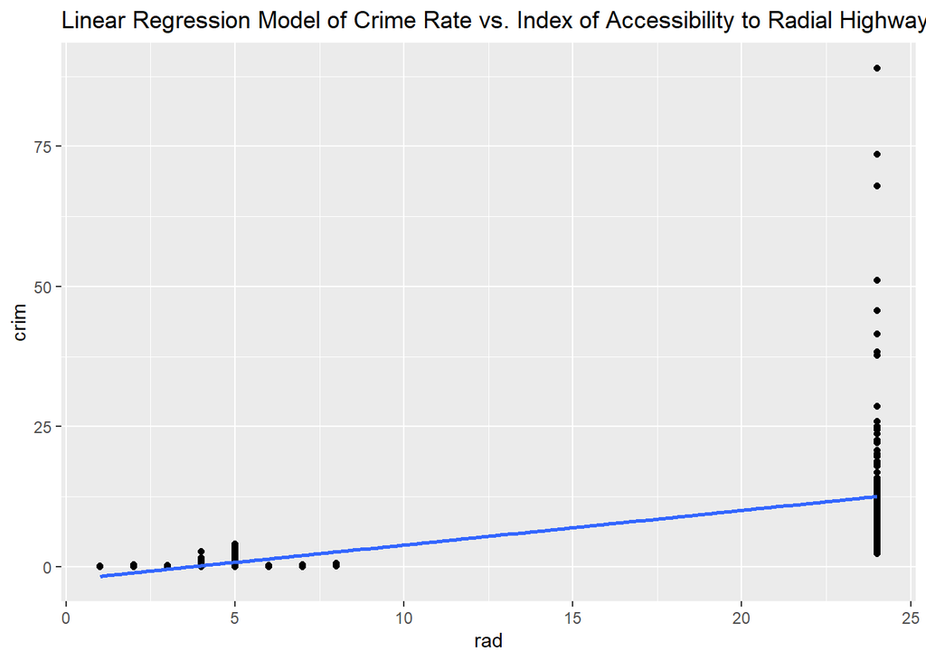

```r
ggplot(radmodel, aes(x = rad, y = crim)) +
  geom_point() +
  geom_smooth(method = "lm", se = FALSE) +
  labs(title = "Linear Regression Model of Crime Rate vs. Index of Accessibility to Radial Highways")
```

```r
taxmodel = lm(crim ~ tax, data = Boston)
summary(taxmodel)
```

```
Call:
lm(formula = crim ~ tax, data = Boston)

Residuals:
    Min      1Q  Median      3Q     Max
-12.513  -2.738  -0.194   1.065  77.696

Coefficients:
             Estimate Std. Error t value Pr(>|t|)
(Intercept) -8.528369   0.815809  -10.45   <2e-16 ***
tax          0.029742   0.001847   16.10   <2e-16 ***
---
Signif. codes:  0 '***' 0.001 '**' 0.01 '*' 0.05 '.' 0.1 ' ' 1

Residual standard error: 6.997 on 504 degrees of freedom
Multiple R-squared:  0.3396,    Adjusted R-squared:  0.3383
F-statistic: 259.2 on 1 and 504 DF,  p-value: < 2.2e-16
```

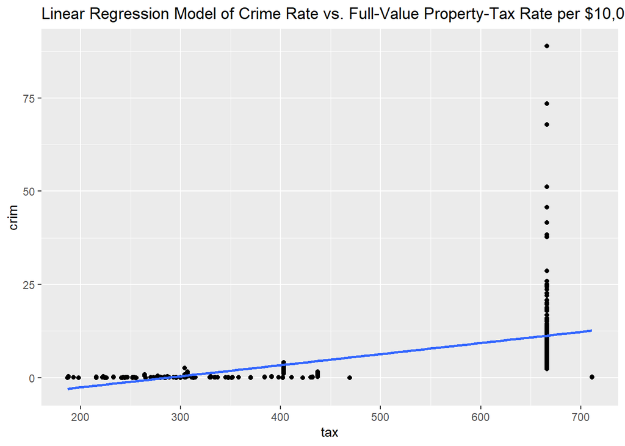

```r
ggplot(taxmodel, aes(x = tax, y = crim)) +
  geom_point() +
  geom_smooth(method = "lm", se = FALSE) +
  labs(title = "Linear Regression Model of Crime Rate vs. Full-Value Property-Tax Rate per $10,000")
```

```r
ptratiomodel = lm(crim ~ ptratio, data = Boston)
summary(ptratiomodel)
```

```
Call:
lm(formula = crim ~ ptratio, data = Boston)

Residuals:
   Min     1Q Median     3Q    Max
-7.654 -3.985 -1.912  1.825 83.353

Coefficients:
            Estimate Std. Error t value Pr(>|t|)
(Intercept) -17.6469     3.1473  -5.607 3.40e-08 ***
ptratio       1.1520     0.1694   6.801 2.94e-11 ***
---
Signif. codes:  0 '***' 0.001 '**' 0.01 '*' 0.05 '.' 0.1 ' ' 1

Residual standard error: 8.24 on 504 degrees of freedom
Multiple R-squared:  0.08407,   Adjusted R-squared:  0.08225
F-statistic: 46.26 on 1 and 504 DF,  p-value: 2.943e-11
```

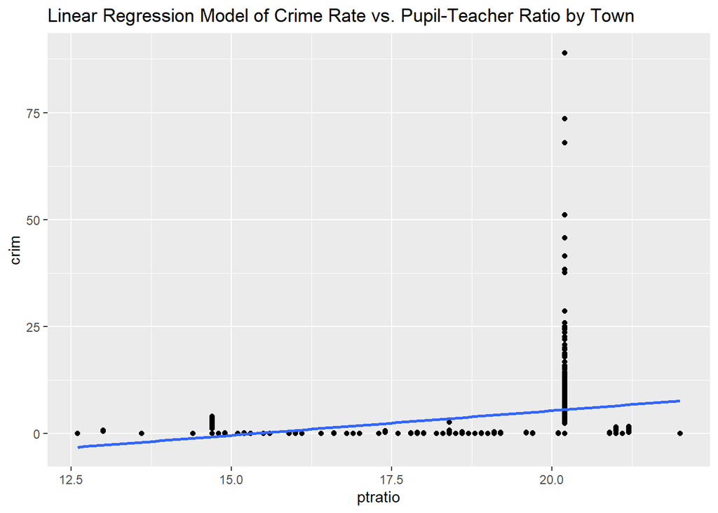

```r
ggplot(ptratiomodel, aes(x = ptratio, y = crim)) +
  geom_point() +
  geom_smooth(method = "lm", se = FALSE) +
  labs(title = "Linear Regression Model of Crime Rate vs. Pupil-Teacher Ratio by Town")
```

```r
lstatmodel = lm(crim ~ lstat, data = Boston)
summary(lstatmodel)
```

```
Call:
lm(formula = crim ~ lstat, data = Boston)

Residuals:
    Min      1Q  Median      3Q     Max
-13.925  -2.822  -0.664   1.079  82.862

Coefficients:
            Estimate Std. Error t value Pr(>|t|)
(Intercept) -3.33054    0.69376  -4.801 2.09e-06 ***
lstat        0.54880    0.04776  11.491  < 2e-16 ***
---
Signif. codes:  0 '***' 0.001 '**' 0.01 '*' 0.05 '.' 0.1 ' ' 1

Residual standard error: 7.664 on 504 degrees of freedom
Multiple R-squared:  0.2076,    Adjusted R-squared:  0.206
F-statistic:   132 on 1 and 504 DF,  p-value: < 2.2e-16
```

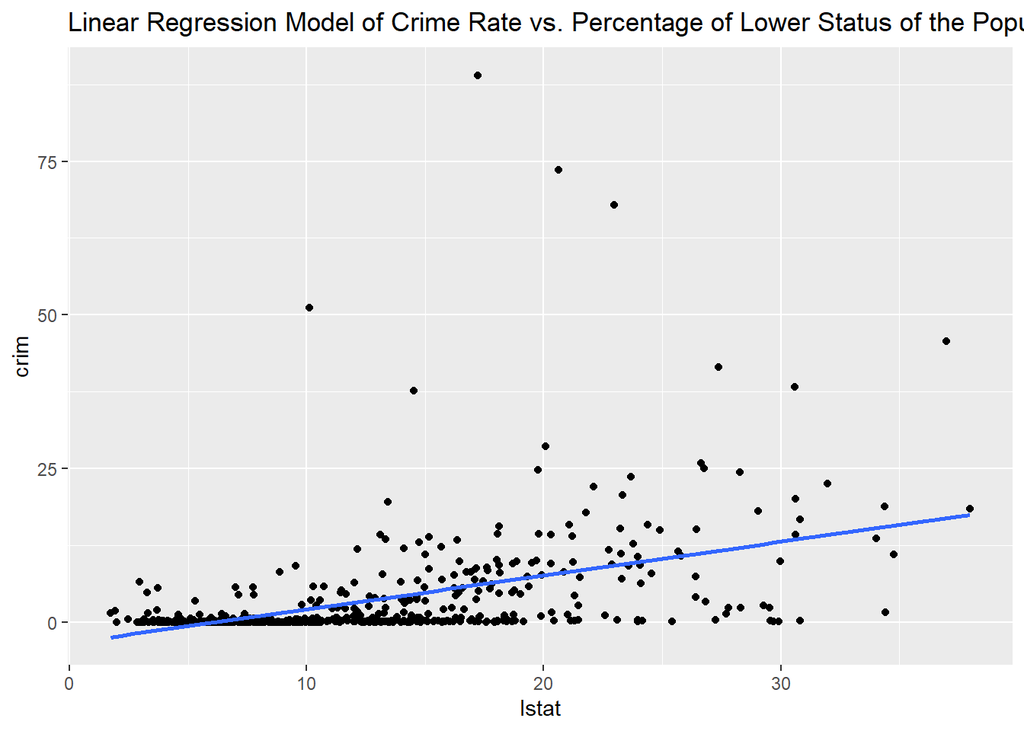

```r
ggplot(lstatmodel, aes(x = lstat, y = crim)) +
  geom_point() +
  geom_smooth(method = "lm", se = FALSE) +
  labs(title = "Linear Regression Model of Crime Rate vs. Percentage of Lower Status of the Population")
```

```r
medvmodel = lm(crim ~ medv, data = Boston)
summary(medvmodel)
```

```
Call:
lm(formula = crim ~ medv, data = Boston)

Residuals:
   Min     1Q Median     3Q    Max
-9.071 -4.022 -2.343  1.298 80.957

Coefficients:
            Estimate Std. Error t value Pr(>|t|)
(Intercept) 11.79654    0.93419   12.63   <2e-16 ***
medv        -0.36316    0.03839   -9.46   <2e-16 ***
---
Signif. codes:  0 '***' 0.001 '**' 0.01 '*' 0.05 '.' 0.1 ' ' 1

Residual standard error: 7.934 on 504 degrees of freedom
Multiple R-squared:  0.1508,    Adjusted R-squared:  0.1491
F-statistic: 89.49 on 1 and 504 DF,  p-value: < 2.2e-16
```

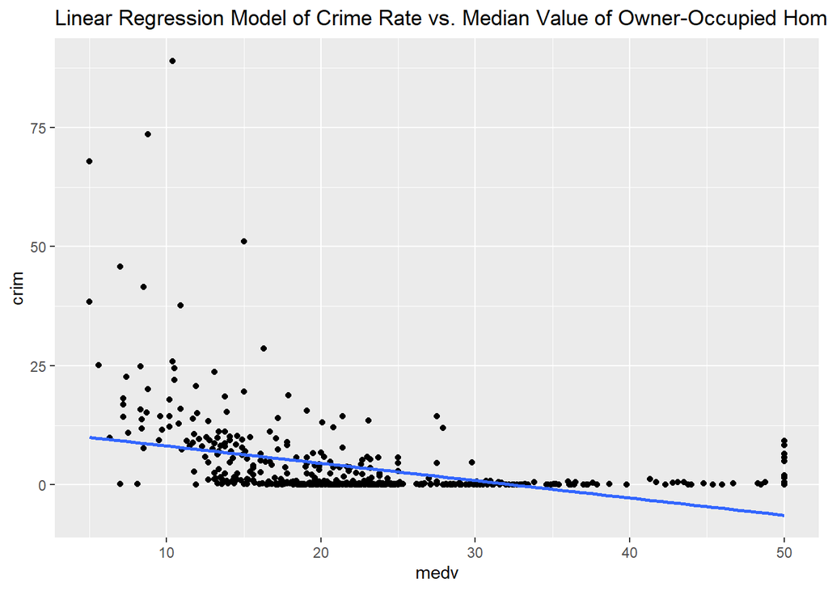

```r
ggplot(medvmodel, aes(x = medv, y = crim)) +
  geom_point() +
  geom_smooth(method = "lm", se = FALSE) +
  labs(title = "Linear Regression Model of Crime Rate vs. Median Value of Owner-Occupied Homes in $1000s")
```

Notably all predictors besides `chas` which is a dummy variable representing if the tract bounds the Charles River or not, have p-values less than 0.05, which suggests that there is a statistically significant association between these predictors and `crim`. We can reject the null hypothesis H0 : $\beta{}_j = 0$ for these predictors.

`indus`,`nox`,`age`,`rad`,`tax`,`ptratio`,`lstat` have a positive coefficient which suggests that as these predictor increases, the `crim` increases. This suggests that the suburbs with more non-retail business acres per town, higher nitrogen oxides concentration, more owner-occupied units built prior to 1940, higher index of accessibility to radial highways, higher tax rates, higher pupil-teacher ratio, or higher percentage of lower status of the population tend to have higher crime rates.

`zn`,`rm`,`dis`,`medv` have a negative coefficient which suggests that as these predictor increases, the `crim` decreases. This suggests that the suburbs with more residential land zoned for lots over 25,000 sq.ft., more average number of rooms per dwelling, longer distances to five Boston employment centres, or higher median value of owner-occupied homes tend to have lower crime rates.

2. Fit a multiple regression model to predict the response using all of the predictors. Describe your results. For which predictors can we reject the null hypothesis H0 : $\beta{}_j = 0$?

**Answer:**

```r
library(tidyverse)

multimodel=lm(crim ~ ., data = Boston)
summary(multimodel)
```

```
Call:
lm(formula = crim ~ ., data = Boston)

Residuals:
   Min     1Q Median     3Q    Max
-8.534 -2.248 -0.348  1.087 73.923

Coefficients:
              Estimate Std. Error t value Pr(>|t|)
(Intercept) 13.7783938  7.0818258   1.946 0.052271 .
zn           0.0457100  0.0187903   2.433 0.015344 *
indus       -0.0583501  0.0836351  -0.698 0.485709
chas        -0.8253776  1.1833963  -0.697 0.485841
nox         -9.9575865  5.2898242  -1.882 0.060370 .
rm           0.6289107  0.6070924   1.036 0.300738
age         -0.0008483  0.0179482  -0.047 0.962323
dis         -1.0122467  0.2824676  -3.584 0.000373 ***
rad          0.6124653  0.0875358   6.997 8.59e-12 ***
tax         -0.0037756  0.0051723  -0.730 0.465757
ptratio     -0.3040728  0.1863598  -1.632 0.103393
lstat        0.1388006  0.0757213   1.833 0.067398 .
medv        -0.2200564  0.0598240  -3.678 0.000261 ***
---
Signif. codes:  0 '***' 0.001 '**' 0.01 '*' 0.05 '.' 0.1 ' ' 1

Residual standard error: 6.46 on 493 degrees of freedom
Multiple R-squared:  0.4493,    Adjusted R-squared:  0.4359
F-statistic: 33.52 on 12 and 493 DF,  p-value: < 2.2e-16
```

As we can see in multi-linear regression model, a lot of the previously significant predictors are no longer significant.

As the output shows, only `zn`, `dis`, `rad` and `medv` have p-values less than 0.05, which suggests that there is a statistically significant association between these predictors and `crim`. We can reject the null hypothesis H0 : $\beta{}_j = 0$ for these predictors.

(c) How do your results from (a) compare to your results from (b)? Create a plot displaying the univariate regression coefficients from (a) on the x-axis, and the multiple regression coefficients from (b) on the y-axis. That is, each predictor is displayed as a single point in the plot. Its coefficient in a simple linear regression model is shown on the x-axis, and its coefficient estimate in the multiple linear regression model is shown on the y-axis.

**Answer:**

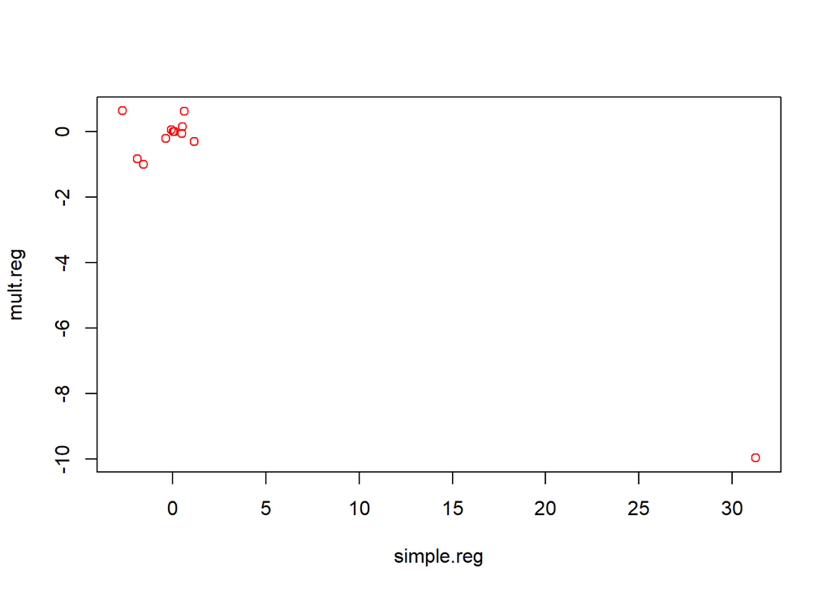

```r
simple.reg <- vector("numeric",0)
simple.reg <- c(simple.reg, znmodel$coefficient[2])
simple.reg <- c(simple.reg, indusmodel$coefficient[2])
simple.reg <- c(simple.reg, chasmodel$coefficient[2])
simple.reg <- c(simple.reg, noxmodel$coefficient[2])
simple.reg <- c(simple.reg, rmmodel$coefficient[2])
simple.reg <- c(simple.reg, agemodel$coefficient[2])
simple.reg <- c(simple.reg, dismodel$coefficient[2])
simple.reg <- c(simple.reg, radmodel$coefficient[2])
simple.reg <- c(simple.reg, taxmodel$coefficient[2])
simple.reg <- c(simple.reg, ptratiomodel$coefficient[2])
simple.reg <- c(simple.reg, lstatmodel$coefficient[2])
simple.reg <- c(simple.reg, medvmodel$coefficient[2])
mult.reg <- vector("numeric", 0)
mult.reg <- c(multimodel$coefficients)
mult.reg <- mult.reg[-1]
plot(simple.reg, mult.reg, col = "red")
```

All predictors seems to be located at top left side of the plot which indicates that for most predictors, the coefficients in the multiple regression model are smaller than in the simple regression model. This is a common occurrence when predictors that are correlated with each other are included in the same model—each predictor’s apparent influence on the response variable is reduced when controlling for other variables.

one point is located at the bottom right side of the plot which indicates that for this predictor (nox) while in the simple regression model, the coefficient is positive, in the multiple regression model, the coefficient is negative. It means that when we look like its individual effects on `crim`, it has a positive effect on crime rate, but when we control for other variables, it has a negative effect on crime rate.

(d) Is there evidence of non-linear association between any of the predictors and the response? To answer this question, for each predictor X, fit a model of the form

$$Y = \beta_0 + \beta_1X + \beta_2X^2 + \beta_3X^3 + \epsilon.$$

**Answer:**

```r
znmultimodel=lm(crim ~ zn + I(zn^2) + I(zn^3), data = Boston)
summary(znmultimodel)
```

```
Call:
lm(formula = crim ~ zn + I(zn^2) + I(zn^3), data = Boston)

Residuals:
   Min     1Q Median     3Q    Max
-4.821 -4.614 -1.294  0.473 84.130

Coefficients:
              Estimate Std. Error t value Pr(>|t|)
(Intercept)  4.846e+00  4.330e-01  11.192  < 2e-16 ***
zn          -3.322e-01  1.098e-01  -3.025  0.00261 **
I(zn^2)      6.483e-03  3.861e-03   1.679  0.09375 .
I(zn^3)     -3.776e-05  3.139e-05  -1.203  0.22954
---
Signif. codes:  0 '***' 0.001 '**' 0.01 '*' 0.05 '.' 0.1 ' ' 1

Residual standard error: 8.372 on 502 degrees of freedom
Multiple R-squared:  0.05824,   Adjusted R-squared:  0.05261
F-statistic: 10.35 on 3 and 502 DF,  p-value: 1.281e-06
```

```r
indusmultimodel=lm(crim ~ indus + I(indus^2) + I(indus^3), data = Boston)
summary(indusmultimodel)
```

```
Call:
lm(formula = crim ~ indus + I(indus^2) + I(indus^3), data = Boston)

Residuals:
   Min     1Q Median     3Q    Max
-8.278 -2.514  0.054  0.764 79.713

Coefficients:
              Estimate Std. Error t value Pr(>|t|)
(Intercept)  3.6625683  1.5739833   2.327   0.0204 *
indus       -1.9652129  0.4819901  -4.077 5.30e-05 ***
I(indus^2)   0.2519373  0.0393221   6.407 3.42e-10 ***
I(indus^3)  -0.0069760  0.0009567  -7.292 1.20e-12 ***
---
Signif. codes:  0 '***' 0.001 '**' 0.01 '*' 0.05 '.' 0.1 ' ' 1

Residual standard error: 7.423 on 502 degrees of freedom
Multiple R-squared:  0.2597,    Adjusted R-squared:  0.2552
F-statistic: 58.69 on 3 and 502 DF,  p-value: < 2.2e-16
```

```r
chasmultimodel=lm(crim ~ chas + I(chas^2) + I(chas^3), data = Boston)
summary(chasmultimodel)
```

```
Call:
lm(formula = crim ~ chas + I(chas^2) + I(chas^3), data = Boston)

Residuals:
   Min     1Q Median     3Q    Max
-3.738 -3.661 -3.435  0.018 85.232

Coefficients: (2 not defined because of singularities)
            Estimate Std. Error t value Pr(>|t|)
(Intercept)   3.7444     0.3961   9.453   <2e-16 ***
chas         -1.8928     1.5061  -1.257    0.209
I(chas^2)         NA         NA      NA       NA
I(chas^3)         NA         NA      NA       NA
---
Signif. codes:  0 '***' 0.001 '**' 0.01 '*' 0.05 '.' 0.1 ' ' 1

Residual standard error: 8.597 on 504 degrees of freedom
Multiple R-squared:  0.003124,  Adjusted R-squared:  0.001146
F-statistic: 1.579 on 1 and 504 DF,  p-value: 0.2094
```

```r
noxmultimodel=lm(crim ~ nox + I(nox^2) + I(nox^3), data = Boston)
summary(noxmultimodel)
```

```
Call:
lm(formula = crim ~ nox + I(nox^2) + I(nox^3), data = Boston)

Residuals:
   Min     1Q Median     3Q    Max
-9.110 -2.068 -0.255  0.739 78.302

Coefficients:
            Estimate Std. Error t value Pr(>|t|)
(Intercept)   233.09      33.64   6.928 1.31e-11 ***
nox         -1279.37     170.40  -7.508 2.76e-13 ***
I(nox^2)     2248.54     279.90   8.033 6.81e-15 ***
I(nox^3)    -1245.70     149.28  -8.345 6.96e-16 ***
---
Signif. codes:  0 '***' 0.001 '**' 0.01 '*' 0.05 '.' 0.1 ' ' 1

Residual standard error: 7.234 on 502 degrees of freedom
Multiple R-squared:  0.297, Adjusted R-squared:  0.2928
F-statistic: 70.69 on 3 and 502 DF,  p-value: < 2.2e-16
```

```r
rmmultimodel=lm(crim ~ rm + I(rm^2) + I(rm^3), data = Boston)
summary(rmmultimodel)
```

```
Call:
lm(formula = crim ~ rm + I(rm^2) + I(rm^3), data = Boston)

Residuals:
    Min      1Q  Median      3Q     Max
-18.485  -3.468  -2.221  -0.015  87.219

Coefficients:
            Estimate Std. Error t value Pr(>|t|)
(Intercept) 112.6246    64.5172   1.746   0.0815 .
rm          -39.1501    31.3115  -1.250   0.2118
I(rm^2)       4.5509     5.0099   0.908   0.3641
I(rm^3)      -0.1745     0.2637  -0.662   0.5086
---
Signif. codes:  0 '***' 0.001 '**' 0.01 '*' 0.05 '.' 0.1 ' ' 1

Residual standard error: 8.33 on 502 degrees of freedom
Multiple R-squared:  0.06779,   Adjusted R-squared:  0.06222
F-statistic: 12.17 on 3 and 502 DF,  p-value: 1.067e-07
```

```r
agemultimodel=lm(crim ~ age + I(age^2) + I(age^3), data = Boston)
summary(agemultimodel)
```

```
Call:
lm(formula = crim ~ age + I(age^2) + I(age^3), data = Boston)

Residuals:
   Min     1Q Median     3Q    Max
-9.762 -2.673 -0.516  0.019 82.842

Coefficients:
              Estimate Std. Error t value Pr(>|t|)
(Intercept) -2.549e+00  2.769e+00  -0.920  0.35780
age          2.737e-01  1.864e-01   1.468  0.14266
I(age^2)    -7.230e-03  3.637e-03  -1.988  0.04738 *
I(age^3)     5.745e-05  2.109e-05   2.724  0.00668 **
---
Signif. codes:  0 '***' 0.001 '**' 0.01 '*' 0.05 '.' 0.1 ' ' 1

Residual standard error: 7.84 on 502 degrees of freedom
Multiple R-squared:  0.1742,    Adjusted R-squared:  0.1693
F-statistic: 35.31 on 3 and 502 DF,  p-value: < 2.2e-16
```

```r
dismultimodel=lm(crim ~ dis + I(dis^2) + I(dis^3), data = Boston)
summary(dismultimodel)
```

```
Call:
lm(formula = crim ~ dis + I(dis^2) + I(dis^3), data = Boston)

Residuals:
    Min      1Q  Median      3Q     Max
-10.757  -2.588   0.031   1.267  76.378

Coefficients:
            Estimate Std. Error t value Pr(>|t|)
(Intercept)  30.0476     2.4459  12.285  < 2e-16 ***
dis         -15.5543     1.7360  -8.960  < 2e-16 ***
I(dis^2)      2.4521     0.3464   7.078 4.94e-12 ***
I(dis^3)     -0.1186     0.0204  -5.814 1.09e-08 ***
---
Signif. codes:  0 '***' 0.001 '**' 0.01 '*' 0.05 '.' 0.1 ' ' 1

Residual standard error: 7.331 on 502 degrees of freedom
Multiple R-squared:  0.2778,    Adjusted R-squared:  0.2735
F-statistic: 64.37 on 3 and 502 DF,  p-value: < 2.2e-16
```

```r
radmultimodel=lm(crim ~ rad + I(rad^2) + I(rad^3), data = Boston)
summary(radmultimodel)
```

```
Call:
lm(formula = crim ~ rad + I(rad^2) + I(rad^3), data = Boston)

Residuals:
    Min      1Q  Median      3Q     Max
-10.381  -0.412  -0.269   0.179  76.217

Coefficients:
             Estimate Std. Error t value Pr(>|t|)
(Intercept) -0.605545   2.050108  -0.295    0.768
rad          0.512736   1.043597   0.491    0.623
I(rad^2)    -0.075177   0.148543  -0.506    0.613
I(rad^3)     0.003209   0.004564   0.703    0.482

Residual standard error: 6.682 on 502 degrees of freedom
Multiple R-squared:    0.4, Adjusted R-squared:  0.3965
F-statistic: 111.6 on 3 and 502 DF,  p-value: < 2.2e-16
```

```r
taxmultimodel=lm(crim ~ tax + I(tax^2) + I(tax^3), data = Boston)
summary(taxmultimodel)
```

```
Call:
lm(formula = crim ~ tax + I(tax^2) + I(tax^3), data = Boston)

Residuals:
    Min      1Q  Median      3Q     Max
-13.273  -1.389   0.046   0.536  76.950

Coefficients:
              Estimate Std. Error t value Pr(>|t|)
(Intercept)  1.918e+01  1.180e+01   1.626    0.105
tax         -1.533e-01  9.568e-02  -1.602    0.110
I(tax^2)     3.608e-04  2.425e-04   1.488    0.137
I(tax^3)    -2.204e-07  1.889e-07  -1.167    0.244

Residual standard error: 6.854 on 502 degrees of freedom
Multiple R-squared:  0.3689,    Adjusted R-squared:  0.3651
F-statistic:  97.8 on 3 and 502 DF,  p-value: < 2.2e-16
```

```r
ptratiomultimodel=lm(crim ~ ptratio + I(ptratio^2) + I(ptratio^3), data = Boston)
summary(ptratiomultimodel)
```

```
Call:
lm(formula = crim ~ ptratio + I(ptratio^2) + I(ptratio^3), data = Boston)

Residuals:
   Min     1Q Median     3Q    Max
-6.833 -4.146 -1.655  1.408 82.697

Coefficients:
              Estimate Std. Error t value Pr(>|t|)
(Intercept)  477.18405  156.79498   3.043  0.00246 **
ptratio      -82.36054   27.64394  -2.979  0.00303 **
I(ptratio^2)   4.63535    1.60832   2.882  0.00412 **
I(ptratio^3)  -0.08476    0.03090  -2.743  0.00630 **
---
Signif. codes:  0 '***' 0.001 '**' 0.01 '*' 0.05 '.' 0.1 ' ' 1

Residual standard error: 8.122 on 502 degrees of freedom
Multiple R-squared:  0.1138,    Adjusted R-squared:  0.1085
F-statistic: 21.48 on 3 and 502 DF,  p-value: 4.171e-13
```

```r
lstatmultimodel=lm(crim ~ lstat + I(lstat^2) + I(lstat^3), data = Boston)
summary(lstatmultimodel)
```

```
Call:
lm(formula = crim ~ lstat + I(lstat^2) + I(lstat^3), data = Boston)

Residuals:
    Min      1Q  Median      3Q     Max
-15.234  -2.151  -0.486   0.066  83.353

Coefficients:
              Estimate Std. Error t value Pr(>|t|)
(Intercept)  1.2009656  2.0286452   0.592   0.5541
lstat       -0.4490656  0.4648911  -0.966   0.3345
I(lstat^2)   0.0557794  0.0301156   1.852   0.0646 .
I(lstat^3)  -0.0008574  0.0005652  -1.517   0.1299
---
Signif. codes:  0 '***' 0.001 '**' 0.01 '*' 0.05 '.' 0.1 ' ' 1

Residual standard error: 7.629 on 502 degrees of freedom
Multiple R-squared:  0.2179,    Adjusted R-squared:  0.2133
F-statistic: 46.63 on 3 and 502 DF,  p-value: < 2.2e-16
```

```r
medvmultimodel=lm(crim ~ medv + I(medv^2) + I(medv^3), data = Boston)
summary(medvmultimodel)
```

```
Call:
lm(formula = crim ~ medv + I(medv^2) + I(medv^3), data = Boston)

Residuals:
    Min      1Q  Median      3Q     Max
-24.427  -1.976  -0.437   0.439  73.655

Coefficients:
              Estimate Std. Error t value Pr(>|t|)
(Intercept) 53.1655381  3.3563105  15.840  < 2e-16 ***
medv        -5.0948305  0.4338321 -11.744  < 2e-16 ***
I(medv^2)    0.1554965  0.0171904   9.046  < 2e-16 ***
I(medv^3)   -0.0014901  0.0002038  -7.312 1.05e-12 ***
---
Signif. codes:  0 '***' 0.001 '**' 0.01 '*' 0.05 '.' 0.1 ' ' 1

Residual standard error: 6.569 on 502 degrees of freedom
Multiple R-squared:  0.4202,    Adjusted R-squared:  0.4167
F-statistic: 121.3 on 3 and 502 DF,  p-value: < 2.2e-16
```

For `zn`, the linear term is significant, but the quadratic and cubic terms are not at the 0.05 level, suggesting a potential but not strong non-linear relationship.

For `indus`, all terms are significant, indicating a strong non-linear relationship.

`chas` is a binary variable, so quadratic and cubic terms are not applicable.

For `nox`, all polynomial terms are significant, suggesting a non-linear relationship.

`rm` does not show significant non-linear terms.

`age` shows significant quadratic and cubic terms, indicating non-linearity.

## 7 Bonus question (20pts)

For multiple linear regression, show that $R^2$ is equal to the correlation between the response vector $\mathbf{y} = (y_1, \ldots, y_n)^T$ and the fitted values $\hat{\mathbf{y}} = (\hat y_1, \ldots, \hat y_n)^T$. That is
$$R^2 = 1 - \frac{\text{RSS}}{\text{TSS}} = [\operatorname{Cor}(\mathbf{y}, \hat{\mathbf{y}})]^2.$$
**Answer:**
$$\begin{align*}
R^2 &= 1 - \frac{\text{RSS}}{\text{TSS}}\\
&=\frac{\text{TSS}}{\text{TSS}} - \frac{\text{RSS}}{\text{TSS}}\\
&=\frac{\text{TSS}-\text{RSS}}{\text{TSS}}\\
&=\frac{\text{ESS}}{\text{TSS}}*\frac{\text{ESS}}{\text{ESS}}\\
&=\frac{[\sum_{i=1}^n(\hat{y}_i-\bar{y})^2]^2}{\sum_{i=1}^n(y_i-\bar{y})^2\sum_{i=1}^n(\hat{y}_i-\bar{y})^2}\\
&={\frac{\sum_{i=1}^n(\hat{y}_i-\bar{y})(y_i-\bar{y})}{\sqrt{\sum_{i=1}^n(y_i-\bar{y})^2}\sqrt{\sum_{i=1}^n(\hat{y}_i-\bar{y})^2}}}^2\\
&=[\operatorname{Cor}(\mathbf{y}, \hat{\mathbf{y}})]^2
\end{align*}$$